# Tpc_5

Diogo Alexandre Alonso De Freitas

2022-10-01

## Enunciado

### 1.

> Sabe-se que nos municípios de uma certa região turística, 40% mais que duplicam a sua população nos meses de verão. Suponha que o acréscimo no consumo de água por cada turista alojado, por dia, pode ser descrito através de uma variável aleatória com distribuição Normal, de média 0,50 m3 e desvio-padrão 0,05 m3.

#### a) Qual a probabilidade do acréscimo no consumo, por turista e por dia, ser inferior a 0,437 m3

$X$ -> acréscimo no consumo de água por cada turista alojado, por dia $X \sim N(0.5, 0.05)$

Para conseguirmo responder a esta pergunta, iremos usar a função *pnorm()*, que irá retornar o valor da função da densidade cumulativa da distribuição normal, dando a média e o desvio padrão da população em causa.

Portanto, podemos dizer que $P(X < 0.437) = pnorm(0.437,0.5,0.05)$

```r
pnorm(0.437,0.5,0.05)
```

```
## [1] 0.1038347
```

#### b) Calcule o maior acréscimo de consumo dos 25% menores acréscimos.

Analisando a pergunta, é notório que, neste caso, iremos precisar de envolver quartis para obter-mos uma respota. Para isso, iremos usar a função *qnorm()* (Esta função lida, por padrão, com áreas abaixo do valor limite fornecido). A função qnorm dá o valor da função de densidade cumulativa inversa da distribuição normal dada uma certa variável aleatória p, uma média populacional μ e um desvio padrão populacional σ. Como na pergunta nos é pedido 25% menores, iremos pedir o quatil 25, obtendo o seguinte: *qnorm(0.25, 0.5, 0.05)*

```r
qnorm(0.25, 0.5, 0.05)
```

```
## [1] 0.4662755
```

#### c) Numa certa unidade de turismo rural casa, a capacidade é de 20 hóspedes. Considerando um momento em que a unidade está totalmente cheia, qual a probabilidade do consumo de água diário aumentar em pelo menos 10,75 m3?

###### Nota: Relembrar o Corolário - - -

> $T = \sum_{i=1}^n X_i \sim N(\mu_T = n\mu, \sigma_T = \sigma \sqrt n)$

```r
pnorm(10.75,0.5*20, 0.05* sqrt(20), lower.tail = FALSE)
```

```
## [1] 0.0003981151
```

#### d) Em relação à casa de turismo rural da alínea anterior:

###### Nota: A função *rnorm* vair criar um vetor de números aleatórios normalmente distribuidos

> 1. Simule uma observação do acréscimo de consumo de água de 20 hóspedes dessa casa de turismo rural. Pretende-se que simule o acréscimo de consumo gerado por cada um desses 20 hóspedes, e que reporte os acréscimos individuais e o acréscimo total (soma dos acréscimos) para esta simulação.

Podemos verificar 20 simulações listadas abaixo

```r
teste_individual <- rnorm(20, 0.5*20, 0.05*sqrt(20))
teste_individual
```

```
##  [1]  9.949219  9.984142  9.918265 10.138647 10.008653 10.181786  9.954255
##  [8]  9.968577  9.964464 10.124595 10.085269  9.921994 10.304359 10.028406
## [15] 10.207192 10.279101  9.951268 10.347009  9.941411 10.296126
```

Para uma melhor análise, podemos utilizar um histograma para ver a distribuição

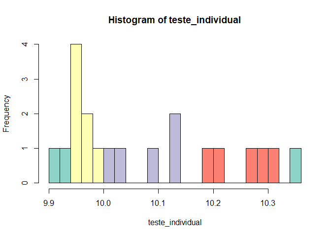

Fazendo a soma dos valores, obtemos o seguinte valor

```r
soma_teste_individual <- sum(teste_individual)
soma_teste_individual
```

```
## [1] 201.5547
```

> 2. Simule 1000 observações nas mesmas condições, guardando apenas a soma para cada uma delas, e, com base nessa simulação, estime a probabilidade que calculou de forma exata em c)

```r
teste_mil <- replicate(1000, sum(rnorm(20, mean=0.5*20, sd=0.05*sqrt(20))))
teste_final <- length(which(teste_mil >= 10.75 * 20)) / length(teste_mil)
teste_final
```

```
## [1] 0
```

```
## A probabilidade é de: 0 %
```

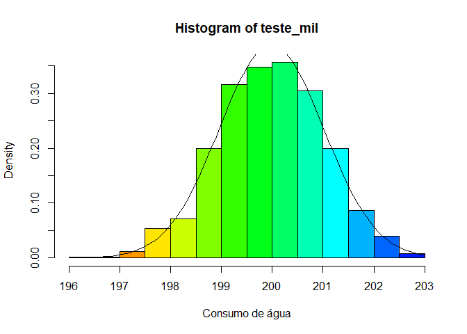

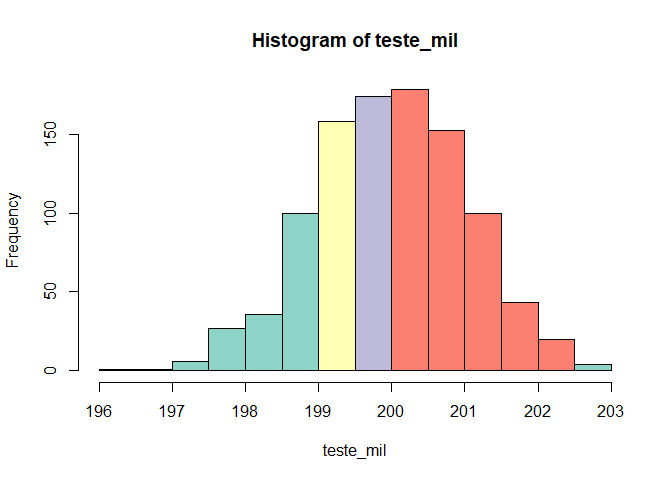